# Lecture 4: Inflation, unemployment, and interest rates

Macro I

Dr Theo Arvanitopoulos

# Inflation, unemployment, and interest rates

We now measure changes in prices, classify people’s labour-market status, and distinguish the money return on a loan from its purchasing-power return.

By the end of this lecture, you should be able to:

- Calculate a price index and distinguish inflation from a change in the price level.
- Classify labour-market status and calculate unemployment, participation, and employment rates.
- Derive labour demand, build aggregate labour supply, and solve for equilibrium.
- Explain wage rigidity and job search using the model and its limitations.
- Calculate nominal and real interest rates, including the exact Fisher relationship.

### 📚 Reading

Case, Fair, and Oster, *Principles of Macroeconomics*, Chapter 7.

# Inflation and the price level

**Inflation** is a sustained increase in the general price level. Individual prices can rise or fall while the overall index increases. A one-off increase in an index raises the price level; continuing inflation requires further increases.

$$\pi_t=\frac{P_t-P_{t-1}}{P_{t-1}}\times100.$$

*Example:* a price index moves from 100 to 110, then to 115.5.

- Inflation is initially 10%, then 5%: this is **disinflation**.
- Prices are still 15.5% above the starting level.
- **Deflation** would require the general price index to fall.

# The consumer price index

The **consumer price index (CPI)** compares the cost of a basket with its cost in the base period. Holding the basket fixed isolates price changes:

$$CPI_t=\frac{\text{cost of the fixed basket at current
prices}}{\text{cost of the same basket at base-period prices}}\times100.$$

The basket contains **four apples and two bananas**.

| Year | Apple price | Banana price | Cost of fixed basket |
| --- | --- | --- | --- |
| 2018 | £1 | £2 | $4(1)+2(2)=£8$ |
| 2020 | £2 | £3 | $4(2)+2(3)=£14$ |

$$CPI_{2018}=100,\qquad CPI_{2020}=\frac{14}{8}100=175.$$

The basket costs $(175-100)/100\times100=75\%$ more than in 2018. This is the **two-year cumulative increase**, not an annual inflation rate.

# Weighted averages

Weights determine how much each price change contributes to the index.

In the original fruit basket, four apples cost £4 and two bananas cost £4. Each accounts for **half the £8 expenditure**, despite the different quantities.

Apples double in price; bananas rise by 50%. Weighting these changes by their initial spending shares gives:

$$P_t^L=100\left[0.5\left(\frac21\right)+0.5\left(\frac32\right)\right]=175.$$

More generally, $s_{j0}$ is item $j$’s share of base-period spending:

$$s_{j0}=\frac{p_{j0}q_{j0}}{\sum_k p_{k0}q_{k0}},\qquad
P_t^L=100\sum_j s_{j0}\frac{p_{jt}}{p_{j0}}.$$

Here $p$ denotes price, $q$ quantity, $0$ the base period, and $t$ the current period. Spending shares sum to one.

# Choosing the basket

Keep the same prices. The original basket has **four apples and two bananas**; the current basket has **two apples and four bananas**.

| Index | Basket held fixed | Calculation |
| --- | --- | --- |
| Laspeyres | Original | $P^L=100\frac{2(4)+3(2)}{1(4)+2(2)}=175$ |
| Paasche | Current | $P^P=100\frac{2(2)+3(4)}{1(2)+2(4)}=160$ |
| Fisher | Combines both | $P^F=\sqrt{175\times160}\approx167.33$ |

Apples became relatively dearer. Switching towards bananas reduces the weight on apples. Laspeyres can overstate the cost-of-living increase; Paasche can understate it.

Fisher takes the **geometric mean** of the two indices and requires both baskets. UK consumer indices update weights and link periods over time.

# Comparing price measures

| Measure | What it covers |
| --- | --- |
| CPI | Consumer goods and services, including imported consumption |
| CPIH | CPI plus owner-occupiers’ housing costs and council tax |
| RPI | Older UK retail-price measure with different coverage and formulae |
| GDP deflator | Domestically produced final output, including investment and exports |
| PPI | Prices of inputs bought or outputs sold by producers |

The GDP deflator excludes imports directly. A rise in imported consumer prices can therefore affect CPI differently from the GDP deflator.

# Measurement and inflation costs

### Measurement

Substitution, changing quality, and new goods complicate comparisons. Different households face different spending patterns and inflation experiences.

### Economic consequences

Unexpected inflation redistributes purchasing power between borrowers and lenders on fixed nominal contracts. Inflation can also obscure relative-price signals and increase the costs of changing prices and managing money balances.

An increase in all nominal incomes alongside prices differs from a price rise with fixed nominal income.

# Labour-market status

**Employment:** people who work, including those temporarily away from a job. Underemployed people have jobs but want, and are available for, more hours; they count as employed.

**Unemployment:** people without work who have actively sought work in the previous four weeks and are available to start within two weeks. The definition also covers certain people waiting to start an arranged job.

**Inactivity:** people who meet neither definition. Discouraged workers who want work but have stopped searching generally fall here.

A student, retiree, or hospital patient is classified by work, search, and availability. Temporary illness does not automatically end employment.

**Survey coverage is separate:** the Labour Force Survey includes private households, NHS accommodation, and student halls, but excludes most other communal establishments. Exclusion from the survey does not mean a person is economically inactive.

Source: [ONS, A guide to labour market statistics](https://www.ons.gov.uk/employmentandlabourmarket/peopleinwork/employmentandemployeetypes/methodologies/aguidetolabourmarketstatistics) (definitions and survey coverage).

# Population and the labour force

For UK statistics, distinguish **people aged 16+** from the **16–64** age band used for headline employment and inactivity rates. People who are neither employed nor unemployed are inactive; some students, retirees, carers, and people with long-term illness fall into this group.

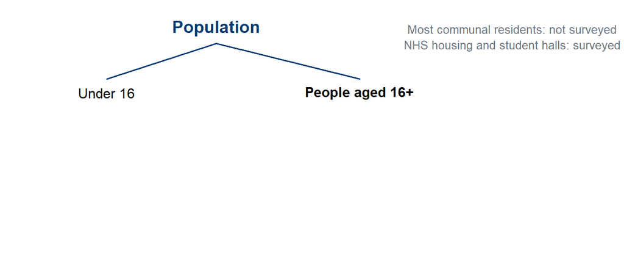

# UK labour-market statistics

**May–July 2026; seasonally adjusted. Release: 15 September 2026.**

| Measure and age band | Latest | Quarter change | Year change |
| --- | --- | --- | --- |
| Employment, 16+ (thousands) | 34,478 | +66 | +243 |
| Employment rate, 16-64 (%) | 75.1 | 0.0 | -0.1 |
| Unemployment, 16+ (thousands) | 1,778 | +11 | +83 |
| Unemployment rate, 16+ (%) | 4.9 | 0.0 | +0.2 |
| Inactive, 16-64 (thousands) | 9,121 | -11 | +12 |
| Inactivity rate, 16-64 (%) | 20.9 | -0.1 | -0.1 |

Changes in levels are **thousands of people**; changes in rates are **percentage points**. Quarter comparison: February–April 2026. Year comparison: May–July 2025.

Source: [ONS Table 1](https://www.ons.gov.uk/employmentandlabourmarket/peopleinwork/employmentandemployeetypes/bulletins/employmentintheuk/september2026). downloaded from ONS. LFS estimates are subject to sampling uncertainty; interpret small quarterly movements cautiously.

# Labour-market rates

Let $E$ be employed people, $U$ unemployed people, and $N$ the population in the chosen age band. The labour force is $LF=E+U$.

*Illustration:* $N=1{,}000$, $E=700$, $U=50$, and 250 people are inactive, so $LF=750$.

| Rate | Formula | Example |
| --- | --- | --- |
| Unemployment, $u$ | $100U/LF$ | $100(50/750)=6.67\%$ |
| Labour force participation, $LFPR$ | $100LF/N$ | $100(750/1000)=75\%$ |
| Employment-to-population, $EPR$ | $100E/N$ | $100(700/1000)=70\%$ |

If 10 unemployed people stop searching, $u=100(40/740)=5.41\%$.

Employment stays at 700: the fall in unemployment reflects people leaving the labour force.

*Use consistent age bands:* ONS headline unemployment uses 16+; employment and inactivity rates use 16–64.

# Types of unemployment

| Type | Mechanism | Example |
| --- | --- | --- |
| Frictional | Search and normal turnover | Graduate searching for a first job |
| Structural | Mismatch of skills or location | Industry closure in one region |
| Cyclical | Weak aggregate demand | Lay-offs during a recession |
| Seasonal | Regular seasonal activity | Tourist employment after summer |

The natural rate is commonly introduced as frictional plus structural unemployment.

**Full employment does not mean zero unemployment.** Institutions and matching conditions can change the natural rate over time.

# The firm’s hiring decision

The model assumes a competitive firm, price-taking in output and factor markets, with capital fixed for the hiring decision.

$$\max_L\ \Pi=P F(K,L)-WL-RK.$$

$P$: output price; $W$: nominal wage; $R$: rental price of capital; $K$: capital; $L$: labour.

$$\frac{\partial\Pi}{\partial L}=P F_L(K,L)-W=0
\quad\Rightarrow\quad MPL=\frac WP=w.$$

The **value** of marginal output equals the nominal wage: $P\,MPL=W$.

Equivalently, marginal output equals the real wage: $MPL=w$.

# Deriving labour demand

With productivity $A>0$, capital $K$, and labour $L$, output is:

$$Y=AK^{1/3}L^{2/3},\qquad A>0.$$

*Marginal product:* differentiate with respect to labour, holding $A$ and $K$ fixed:
$$MPL=\frac23 AK^{1/3}L^{-1/3}.$$

*Hiring condition:* set marginal product equal to the real wage $w=W/P$:
$$\frac23 AK^{1/3}L^{-1/3}=w.$$

*Labour demand:* rearrange and cube both sides:
$$L^{1/3}=\frac{2AK^{1/3}}{3w}
\quad\Rightarrow\quad
L^D=\left(\frac{2AK^{1/3}}{3w}\right)^3
=\frac{8A^3K}{27w^3}.$$

Additional workers share fixed capital, so marginal product falls. A higher wage reduces labour demanded; higher $A$ or $K$ raises it.

# Labour demand

For $A=3/2$ and $K=100$, $L^D=100/w^3$. The plotted curve follows this equation.

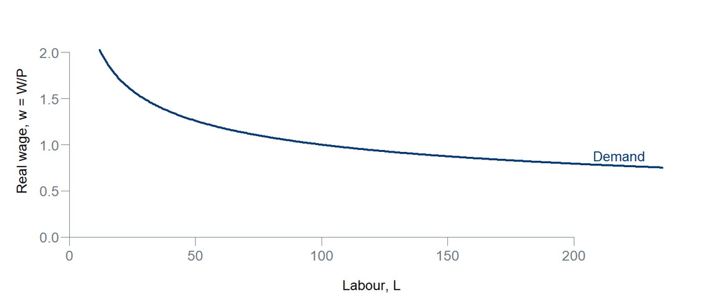

# Labour-demand shifts

A productivity improvement from $A=1.5$ to $A=1.8$ increases labour demanded at $w=1$ from 100 to 172.8. Capital stays at 100.

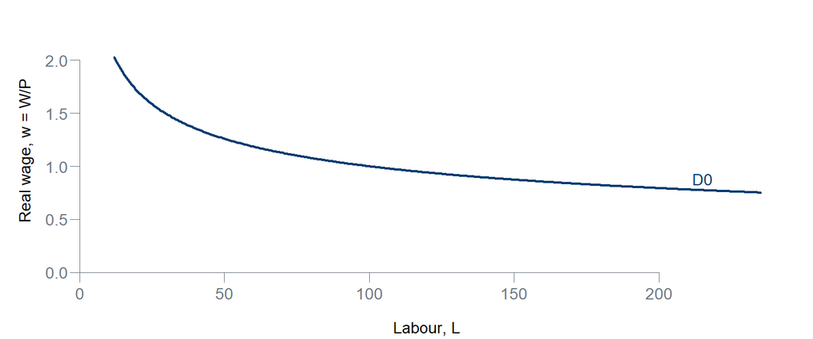

# Work and leisure

A worker divides available time between paid work and leisure. An extra hour of leisure means giving up an hour’s earnings.

- **Substitution effect:** a higher wage makes leisure more expensive, encouraging more work.
- **Income effect:** higher income can increase desired leisure, encouraging less work.

The net effect depends on preferences. In the following example, the substitution effect dominates, so a higher real wage increases hours supplied.

# Individual and aggregate labour supply

Each worker supplies $h=10w$ hours at real wage $w$. For ten identical workers, **add hours at the same wage**: $L^S=10h=100w$.

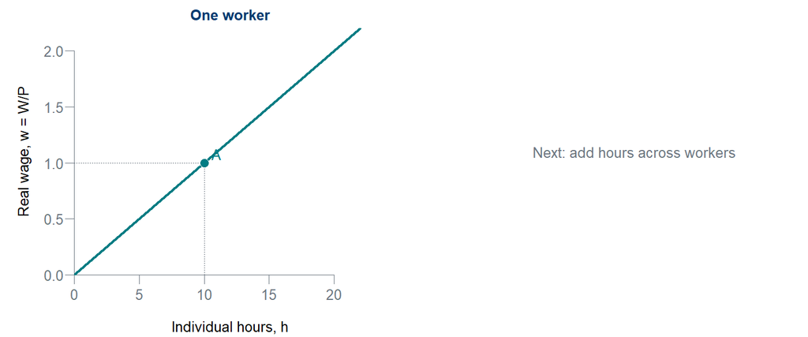

At w = 1, one worker supplies 10 hours

# Labour-supply shifts

Migration, labour-force participation, non-labour income, and taxes can shift supply. Their effects depend on preferences and circumstances.

Here an increase in the number of otherwise identical workers changes $L^S=100w$ to $L^S=140w$.

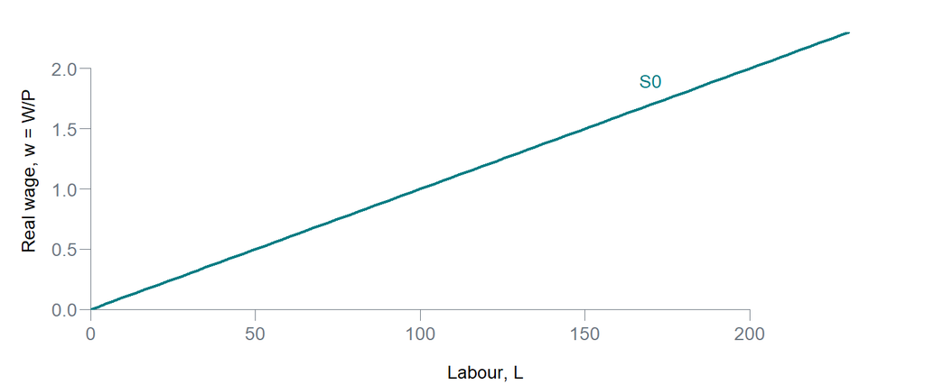

# Labour-market equilibrium

For $A=3/2$ and $K=100$, labour demand is $L^D=100/w^3$, while supply is $L^S=100w$. Equilibrium equates the two.

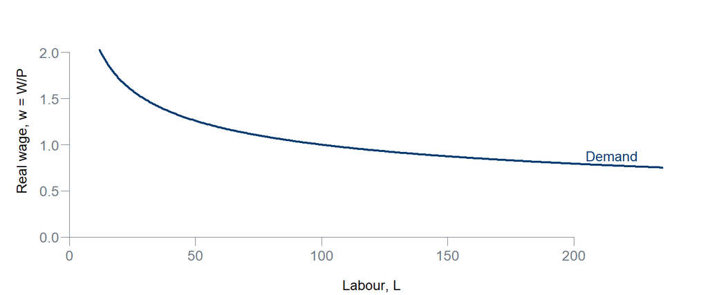

# A wage above equilibrium

At a real wage of $\bar w=1.25$, $L^D=100/1.25^3=51.2$, while $L^S=125$. Excess supply is **73.8 labour units**.

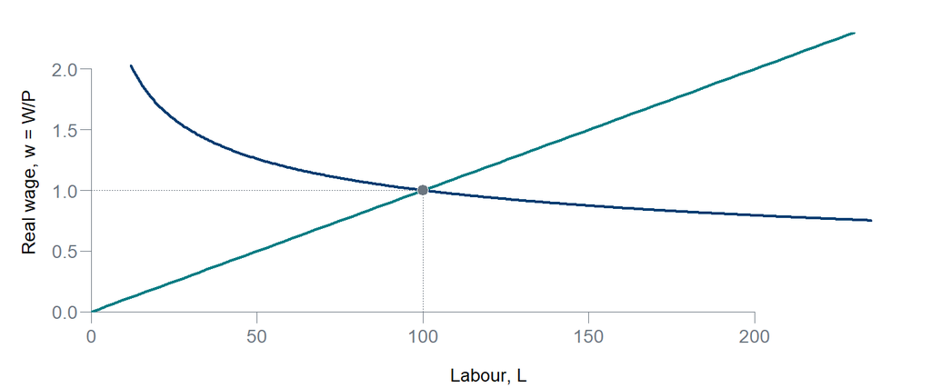

# Wage rigidity

| Mechanism | Why wages may remain above clearing levels |
| --- | --- |
| Wage floors | A legal minimum constrains downward adjustment |
| Collective bargaining | Negotiated wages reflect worker and employer bargaining |
| Efficiency wages | Higher pay may reduce turnover, improve recruitment, or discourage shirking |
| Contracts and adjustment | Wages may adjust slowly after a fall in labour demand |

- An efficiency wage can be a profitable choice if higher pay improves productivity.
- The wage-floor diagram assumes competition; employment effects can differ under other market structures.
- Its gap is in labour units, and converting it to unemployed people requires fixed hours per worker.

# Job search and matching

Even with flexible wages, workers and jobs take time to match because skills, locations, and information differ.

- **Frictional unemployment:** people search between jobs, so vacancies and unemployment coexist.
- **Structural unemployment:** changing industries or locations require retraining or relocation.

In the next Keynesian block, lower spending reduces production and hiring. This provides the link to **cyclical unemployment**.

# Nominal interest rates

The nominal rate measures the premium in money over a specified period:

$$i=\frac{\text{repayment}-\text{principal}}{\text{principal}}.$$

For a £1,000 one-year loan repaid as £1,100:
$$i=\frac{1100-1000}{1000}=0.10=10\%.$$

The borrower pays 10% more pounds. Whether those pounds buy 10% more goods depends on inflation over the same year.

# Real interest and purchasing power

A £1,000 loan at nominal interest $i=10\%$ returns £1,100. With inflation $\pi=6\%$, that repayment buys $1100/1.06=£1,037.74$ at today’s prices.

$$1+r=\frac{1+i}{1+\pi},\qquad
r=\frac{1+i}{1+\pi}-1=\frac{i-\pi}{1+\pi}.$$

$$r=\frac{0.10-0.06}{1.06}=0.0377\approx3.77\%.$$

The **real interest rate**, $r$, measures the gain in purchasing power. For modest rates, $r\approx i-\pi=4\%$ is a useful approximation. Enter rates as decimals in the exact formula.

# Expected and realised returns

When a loan is agreed, future inflation is uncertain. Borrowers and lenders use **expected inflation** to assess the expected real return.

After the year ends, actual inflation determines the realised real return. Unexpectedly high inflation reduces the lender’s purchasing-power return on a fixed nominal loan.

*Example:* at zero nominal interest and 4% inflation, the exact real return is $1/1.04-1=-3.85\%$. The account balance stays constant while its purchasing power falls.

# Loanable funds

Savers supply funds; households, firms, and governments borrow. A higher real interest rate can encourage saving and discourage investment, under the assumptions illustrated.

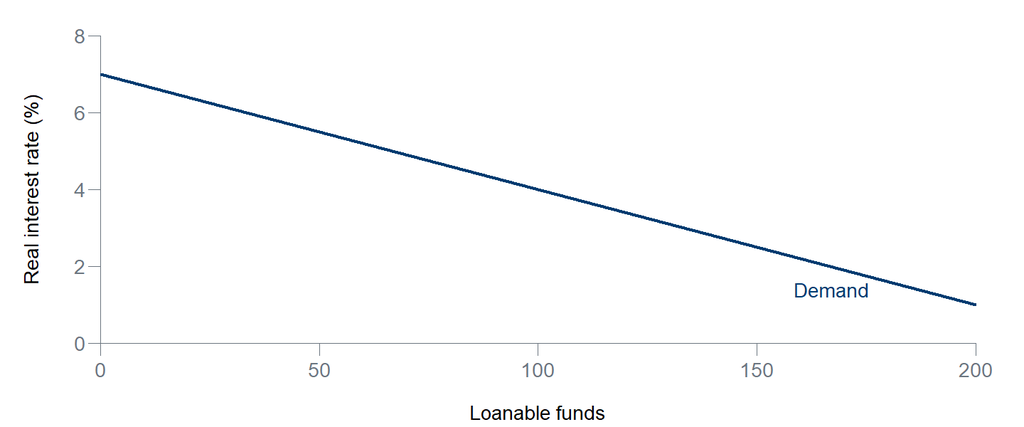

# Practice

1. In the fruit example, calculate the index if bananas cost £4 in 2020.
2. Explain why someone leaving the labour force can reduce the unemployment rate.
3. With $L^D=100/w^3$, calculate labour demand at $w=2$.
4. Calculate the exact real return when $i=5\%$, $\pi=3\%$.

# Summary

- Price indices weight different goods. Inflation is a percentage change in an index over a stated period.
- Labour-force status and the denominator determine how to interpret a labour-market rate.
- Profit maximisation yields $MPL=w$. Supply, demand, and their shifts determine the competitive equilibrium.
- Wage rigidity and search help explain persistent unemployment; weak demand adds a cyclical mechanism.
- The exact real return is $(1+i)/(1+\pi)-1$.